# Ordination on FC data

## Load libraries

[`PhenoFlow`](https://github.com/rprops/PhenoFlow) is used to process data. The aim of this package is to obtain diversity estimates from FC data. It requires several FC oriented packages such as `flowViz` and `flowCore`, as well as community ecology package `vegan`, see their github `libraries.R` script for package download.

Alternatively, the `Phenoflow` functions can be sourced from `MRM.parameters.R`, which have slightly different names and input arguments in some cases. The`Fingerprint.R` Rscript is also included in this github repository, and was used to guide the FC analyses shown below and [here](http://rprops.github.io/PhenoFlow/).

```r
library(Phenoflow)
source("MRM.parameters.R")

library(tidyverse)
library(magrittr)

library(skimr)
library(GGally)

library(factoextra)
```

## Data input

Note that not all the timepoints for FC data are contained within the environmental database. The environomental data timepoints indicate that the sample was selected for biomass related analyses.

The total number of initial `.fcs` files was 516. We have made some data pre selection in the background to reduce the number of files hosted by github. Specifically, we kept 231 files corresponding to total cell count stain and timepoints from 1 to 7.

**Side note**: naming of files is important. What is good/bad about the file names?  
The following hint can help you when selecting samples in batch from your terminal:

`ls *.fcs > list_files`

`grep "TCC_TP0[1-7]" list_files > selected_TCC_list_files`

`mkdir selected`

`while read file; do cp "$file" selected; done < selected_TCC_list_files`

```r
flowData <- flowCore::read.flowSet(path = "data/Run001_060420_060520", pattern = ".fcs")
EnvData <- readxl::read_excel("data/sample.database.xlsx", sheet = "Chemical_data")
```

## Data exploration and wrangling

It’s always important to explore the data prior to any analyses (e.g., look at the distribution of the data).

For **environmental data**, we can look at the structure of the dataframe using base functions. However, there are more sophisticated functions from packages like `skimr` and `GGally` that we can use to obtain additional information quickly.

To explore **FC data**, we need to learn about flowSet objects.

Classes in `flowCore`

- flowFrame - a class representing the data contained in a FCS file.
1. raw measurement
2. keywords in the FCS files
3. annotation for parameters (stains, sample names, range)
- flowSet - a collection of flowFrame.

There are several options to work with a flowSet object, such as:

- [, [[, $ , @ - subsetting
- sampleNames, colnames - names
- phenoData, pData - metadata
- fsApply - apply family, flowSet-specific iterator

**Side note**: `%<>%` might be a new operator for you. It’s from the `magrittr` package and represents pipe and assign.

```r
str(EnvData)
```

```
tibble [174 × 45] (S3: tbl_df/tbl/data.frame)
 $ Number                     : num [1:174] 1 2 3 4 5 6 7 8 9 10 ...
 $ Sample.Id                  : chr [1:174] "SW001" "SW002" "SW003" "SW004" ...
 $ Property                   : chr [1:174] "RES01" "RES01" "RES02" "RES02" ...
 $ Building.Id                : chr [1:174] "Ameet Pinto" "Ameet Pinto" "Ben Gincley" "Ben Gincley" ...
 $ Tap.type                   : chr [1:174] "P" "P" "P" "P" ...
 $ Time.point                 : chr [1:174] "TP01" "TP07" "TP01" "TP07" ...
 $ Duration                   : chr [1:174] "0" "30" "0" "30" ...
 $ Replicate                  : chr [1:174] "R01" "R01" "R01" "R01" ...
 $ Run                        : chr [1:174] "Run#001" "Run#001" "Run#001" "Run#001" ...
 $ Run_date                   : chr [1:174] "Run#001_060420" "Run#001_060420" "Run#001_060420" "Run#001_060420" ...
 $ Date                       : POSIXct[1:174], format: "2020-06-04" "2020-06-04" ...
 $ Season                     : chr [1:174] "Summer" "Summer" "Summer" "Summer" ...
 $ Person.responsible         : chr [1:174] "Solize Vosloo, Linxuan Huo & Ameet Pinto" "Solize Vosloo, Linxuan Huo & Ameet Pinto" "Solize Vosloo, Linxuan Huo & Ben Gincley" "Solize Vosloo, Linxuan Huo & Ben Gincley" ...
 $ Temperature.R1             : num [1:174] 22.3 17 19.3 16 24.1 16.6 23.8 15.5 23.9 14.9 ...
```

[output cut: 31 more lines]

```r
skimr::skim(EnvData)
```

Data summary

| Name | EnvData |
| --- | --- |
| Number of rows | 174 |
| Number of columns | 45 |
| _______________________ |  |
| Column type frequency: |  |
| character | 13 |
| numeric | 31 |
| POSIXct | 1 |
| ________________________ |  |
| Group variables | None |

**Variable type: character**

| skim_variable | n_missing | complete_rate | min | max | empty | n_unique | whitespace |
| --- | --- | --- | --- | --- | --- | --- | --- |
| Sample.Id | 0 | 1.00 | 5 | 12 | 0 | 174 | 0 |
| Property | 0 | 1.00 | 5 | 5 | 0 | 11 | 0 |
| Building.Id | 0 | 1.00 | 2 | 13 | 0 | 8 | 0 |
| Tap.type | 0 | 1.00 | 1 | 2 | 0 | 2 | 0 |
| Time.point | 0 | 1.00 | 4 | 4 | 0 | 5 | 0 |
| Duration | 0 | 1.00 | 1 | 3 | 0 | 5 | 0 |
| Replicate | 0 | 1.00 | 3 | 3 | 0 | 3 | 0 |
| Run | 0 | 1.00 | 7 | 7 | 0 | 6 | 0 |
| Run_date | 0 | 1.00 | 14 | 14 | 0 | 12 | 0 |
| Season | 0 | 1.00 | 4 | 6 | 0 | 2 | 0 |
| Person.responsible | 0 | 1.00 | 27 | 57 | 0 | 6 | 0 |
| Ammonium.R2 | 9 | 0.95 | 3 | 19 | 0 | 57 | 0 |
| Nitrate.R2 | 9 | 0.95 | 1 | 18 | 0 | 15 | 0 |

**Variable type: numeric**

| skim_variable | n_missing | complete_rate | mean | sd | p0 | p25 | p50 | p75 | p100 | hist |
| --- | --- | --- | --- | --- | --- | --- | --- | --- | --- | --- |
| Number | 0 | 1.00 | 87.50 | 50.37 | 1.00 | 44.25 | 87.50 | 130.75 | 174.00 | ▇▇▇▇▇ |
| Temperature.R1 | 8 | 0.95 | 20.74 | 2.19 | 14.90 | 19.30 | 20.70 | 22.00 | 27.30 | ▁▆▇▂▁ |
| Temperature.R2 | 8 | 0.95 | 20.74 | 2.19 | 14.90 | 19.30 | 20.70 | 22.20 | 27.30 | ▁▇▇▃▁ |
| pH.R1 | 8 | 0.95 | 9.38 | 0.23 | 8.53 | 9.24 | 9.36 | 9.54 | 9.87 | ▁▁▇▇▃ |
| pH.R2 | 8 | 0.95 | 9.39 | 0.21 | 8.70 | 9.26 | 9.36 | 9.54 | 9.87 | ▁▂▇▅▂ |
| Conductivity.R1 | 8 | 0.95 | 204.55 | 81.06 | 164.10 | 177.02 | 195.85 | 216.12 | 1197.70 | ▇▁▁▁▁ |
| Conductivity.R2 | 35 | 0.80 | 202.39 | 21.02 | 171.30 | 179.30 | 200.60 | 217.10 | 235.20 | ▇▃▃▇▆ |
| Dissolved.oxygen.R1 | 8 | 0.95 | 11.13 | 1.41 | 8.23 | 10.02 | 10.95 | 11.92 | 15.34 | ▂▇▆▂▁ |
| Dissolved.oxygen.R2 | 35 | 0.80 | 11.28 | 1.52 | 8.23 | 10.07 | 11.07 | 12.06 | 15.51 | ▂▇▆▂▁ |
| Total.chlorine.R1 | 8 | 0.95 | 1.81 | 0.83 | 0.00 | 1.35 | 2.04 | 2.40 | 2.90 | ▃▂▃▇▆ |
| Total.chlorine.R2 | 8 | 0.95 | 1.80 | 0.83 | 0.00 | 1.35 | 2.06 | 2.40 | 3.00 | ▃▂▃▇▆ |
| Total.chlorine.R3 | 9 | 0.95 | 1.79 | 0.82 | 0.00 | 1.33 | 2.02 | 2.40 | 2.98 | ▃▂▅▇▆ |
| Ammonium.R1 | 9 | 0.95 | 0.55 | 0.14 | 0.12 | 0.47 | 0.57 | 0.61 | 0.95 | ▁▂▇▃▁ |
| Ammonium.R3 | 9 | 0.95 | 0.90 | 4.55 | 0.10 | 0.47 | 0.54 | 0.61 | 59.00 | ▇▁▁▁▁ |
| Nitrate.R1 | 9 | 0.95 | 0.67 | 0.21 | 0.01 | 0.50 | 0.70 | 0.80 | 1.20 | ▁▂▇▃▁ |
| Nitrate.R3 | 9 | 0.95 | 0.70 | 0.21 | 0.01 | 0.60 | 0.70 | 0.80 | 1.30 | ▁▅▇▆▁ |
| Nitrite.R1 | 9 | 0.95 | 0.04 | 0.11 | -0.01 | 0.00 | 0.01 | 0.03 | 0.94 | ▇▁▁▁▁ |
| Nitrite.R2 | 9 | 0.95 | 0.03 | 0.07 | 0.00 | 0.00 | 0.01 | 0.03 | 0.61 | ▇▁▁▁▁ |
| Nitrite.R3 | 9 | 0.95 | 0.03 | 0.08 | 0.00 | 0.00 | 0.01 | 0.03 | 0.85 | ▇▁▁▁▁ |
| Total.organic.carbon.R1 | 40 | 0.77 | 317.10 | 468.54 | 105.39 | 177.29 | 201.38 | 280.66 | 5109.42 | ▇▁▁▁▁ |
| Total.organic.carbon.R2 | 38 | 0.78 | 317.30 | 471.73 | 102.72 | 180.84 | 201.54 | 277.79 | 5197.55 | ▇▁▁▁▁ |
| Total.organic.carbon.R3 | 40 | 0.77 | 320.91 | 469.69 | 110.28 | 181.78 | 209.25 | 285.27 | 5143.41 | ▇▁▁▁▁ |
| Dissolved.organic.carbon.R1 | 129 | 0.26 | 188.56 | 22.18 | 168.12 | 181.27 | 183.59 | 189.72 | 318.91 | ▇▂▁▁▁ |
| Dissolved.organic.carbon.R2 | 129 | 0.26 | 185.82 | 23.61 | 173.00 | 177.24 | 182.22 | 185.55 | 331.70 | ▇▁▁▁▁ |
| Dissolved.organic.carbon.R3 | 132 | 0.24 | 189.44 | 24.05 | 173.77 | 178.63 | 184.61 | 188.56 | 329.17 | ▇▁▁▁▁ |
| Total.nitrogen.R1 | 38 | 0.78 | 53.52 | 9.60 | 45.36 | 48.59 | 50.57 | 54.01 | 95.47 | ▇▁▁▁▁ |
| Total.nitrogen.R2 | 42 | 0.76 | 52.80 | 7.66 | 44.91 | 48.54 | 50.44 | 53.50 | 88.96 | ▇▁▁▁▁ |
| Total.nitrogen.R3 | 37 | 0.79 | 53.71 | 9.12 | 45.54 | 48.91 | 50.96 | 53.75 | 93.27 | ▇▁▁▁▁ |
| Total.dissolved.nitrogen.R1 | 129 | 0.26 | 50.90 | 2.10 | 45.23 | 50.22 | 51.31 | 52.28 | 54.81 | ▁▂▅▇▂ |
| Total.dissolved.nitrogen.R2 | 130 | 0.25 | 50.54 | 2.27 | 46.01 | 48.69 | 50.74 | 52.47 | 54.60 | ▃▅▇▅▅ |
| Total.dissolved.nitrogen.R3 | 129 | 0.26 | 50.69 | 2.24 | 45.65 | 49.84 | 50.69 | 52.01 | 59.12 | ▂▇▆▁▁ |

**Variable type: POSIXct**

| skim_variable | n_missing | complete_rate | min | max | median | n_unique |
| --- | --- | --- | --- | --- | --- | --- |
| Date | 0 | 1 | 2020-06-04 | 2020-11-13 | 2020-08-27 12:00:00 | 12 |

```r
EnvData %<>% tibble::column_to_rownames("Sample.Id") %>% dplyr::select(Property,
    Season, ends_with(".R1")) %>% rename_at(vars(ends_with(".R1")), funs(sub(".R1",
    "", .))) %>% dplyr::select(!ends_with(".carbon")) %>% dplyr::select(-Total.dissolved.nitrogen,
    -Total.nitrogen, -Nitrite) %>% dplyr::rename(DO = "Dissolved.oxygen", Chlorine = "Total.chlorine")

summary(EnvData)
```

```
   Property            Season           Temperature          pH
 Length:174         Length:174         Min.   :14.90   Min.   :8.530
 Class :character   Class :character   1st Qu.:19.30   1st Qu.:9.240
 Mode  :character   Mode  :character   Median :20.70   Median :9.360
                                       Mean   :20.74   Mean   :9.379
                                       3rd Qu.:22.00   3rd Qu.:9.537
                                       Max.   :27.30   Max.   :9.870
                                       NA's   :8       NA's   :8
  Conductivity          DO           Chlorine        Ammonium
 Min.   : 164.1   Min.   : 8.23   Min.   :0.000   Min.   :0.1200
 1st Qu.: 177.0   1st Qu.:10.02   1st Qu.:1.350   1st Qu.:0.4700
 Median : 195.8   Median :10.95   Median :2.040   Median :0.5700
 Mean   : 204.5   Mean   :11.13   Mean   :1.808   Mean   :0.5536
 3rd Qu.: 216.1   3rd Qu.:11.92   3rd Qu.:2.400   3rd Qu.:0.6100
 Max.   :1197.7   Max.   :15.34   Max.   :2.900   Max.   :0.9500
 NA's   :8        NA's   :8       NA's   :8       NA's   :9
    Nitrate
 Min.   :0.0060
 1st Qu.:0.5000
 Median :0.7000
 Mean   :0.6687
 3rd Qu.:0.8000
 Max.   :1.2000
 NA's   :9
```

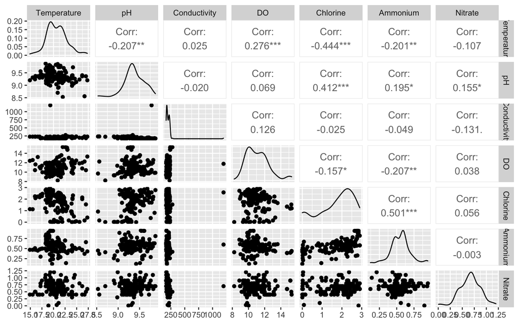

```r
EnvData %<>% tidyr::drop_na()

GGally::ggpairs(EnvData %>% dplyr::select_if(is.numeric))
```

```r
EnvData %<>% mutate(Conductivity = case_when(rownames(.) == "SW135" ~ 197.7, TRUE ~
    Conductivity))


###################################################################

class(flowData)
```

```
[1] "flowSet"
attr(,"package")
[1] "flowCore"
```

```r
summary(flowData)[1]
```

```
$`B01 COM02_TCC_TP02_R1.fcs`
             FSC-A      SSC-A     FL1-A      FL2-A      FL3-A     FL4-A
Min.         0.000      0.000    447.00     90.000      0.000    0.0000
1st Qu.    758.000    641.000   1726.00   1179.750   1901.750  138.0000
Median    2278.000   1631.500  10179.50   4243.000   3699.000  413.0000
Mean      7735.003   3951.744  31022.42   9436.412   6257.546  486.9231
3rd Qu.   6320.750   3820.250  41645.75  12087.000   6746.250  683.0000
             FSC-H      SSC-H     FL1-H      FL2-H      FL3-H     FL4-H
Min.         0.000      0.000    801.00     89.000      0.000    0.0000
1st Qu.   1492.000   2677.000   1235.75    867.000   1620.000  274.0000
Median    3122.500   3651.000   6093.50   2500.000   2743.000  464.0000
Mean      7533.966   5485.005  16763.42   5099.475   4034.043  553.0911
3rd Qu.   6925.750   5311.750  23338.25   6565.750   4555.500  715.0000
           Width     Time
Min.     17.0000 139.0000
1st Qu.  53.0000 343.0000
Median   92.0000 544.0000
Mean     93.5713 544.9827
3rd Qu. 123.0000 748.0000
 [ reached getOption("max.print") -- omitted 1 row ]
```

```r
head(sampleNames(flowData))
```

```
[1] "B01 COM02_TCC_TP02_R1.fcs" "B01 COM03_TCC_TP02_R1.fcs"
[3] "B01 COM05_TCC_TP02_R1.fcs" "B01 RES01_TCC_TP02_R1.fcs"
[5] "B01 RES03_TCC_TP02_R1.fcs" "B01 RES05_TCC_TP02_R1.fcs"
```

```r
colnames(flowData)
```

```
 [1] "FSC-A" "SSC-A" "FL1-A" "FL2-A" "FL3-A" "FL4-A" "FSC-H" "SSC-H" "FL1-H"
[10] "FL2-H" "FL3-H" "FL4-H" "Width" "Time"
```

```r
tail(flowCore::pData(flowData))
```

```
                                               name
G07 COM05_TCC_TP07_R3.fcs G07 COM05_TCC_TP07_R3.fcs
G07 COM06_TCC_TP06_R3.fcs G07 COM06_TCC_TP06_R3.fcs
G07 RES02_TCC_TP06_R3.fcs G07 RES02_TCC_TP06_R3.fcs
G07 RES02_TCC_TP07_R3.fcs G07 RES02_TCC_TP07_R3.fcs
G07 RES04_TCC_TP06_R3.fcs G07 RES04_TCC_TP06_R3.fcs
G07 RES04_TCC_TP07_R3.fcs G07 RES04_TCC_TP07_R3.fcs
```

```r
flowData[[1]]
```

```
flowFrame object 'B01 COM02_TCC_TP02_R1.fcs'
with 10000 cells and 14 observables:
      name    desc    range minRange maxRange
$P1  FSC-A   FSC-A 16777216        0 16777215
$P2  SSC-A   SSC-A 16777216        0 16777215
$P3  FL1-A  FITC-A 16777216        0 16777215
$P4  FL2-A    PE-A 16777216        0 16777215
$P5  FL3-A PerCP-A 16777216        0 16777215
$P6  FL4-A   APC-A 16777216        0 16777215
$P7  FSC-H   FSC-H 16777216        0 16777215
$P8  SSC-H   SSC-H 16777216        0 16777215
$P9  FL1-H  FITC-H 16777216        0 16777215
$P10 FL2-H    PE-H 16777216        0 16777215
$P11 FL3-H PerCP-H 16777216        0 16777215
$P12 FL4-H   APC-H 16777216        0 16777215
$P13 Width   Width 16777216        0 16777215
$P14  Time    Time 16777216        0 16777215
248 keywords are stored in the 'description' slot
```

## Pre-processing

### Transformations

Environmental data have different units as well as scales, therefore some type of nomalization has to be performed. We will center (subtract variable means from each observation) and scale (multiply each measurement by a scalar factor so that the resulting feature has a variance of one) to ensures equal contribution from each variable.

There’s several transformations that can be applied to FC data. In this tutorial, FC data will be transformed by arcsinh, which improves the visualization of data with a low variance and helps data appear more normal by:

1. Allowing for negative values to be included
2. Providing a linear representation around 0
3. Smooth transition of values between extremes

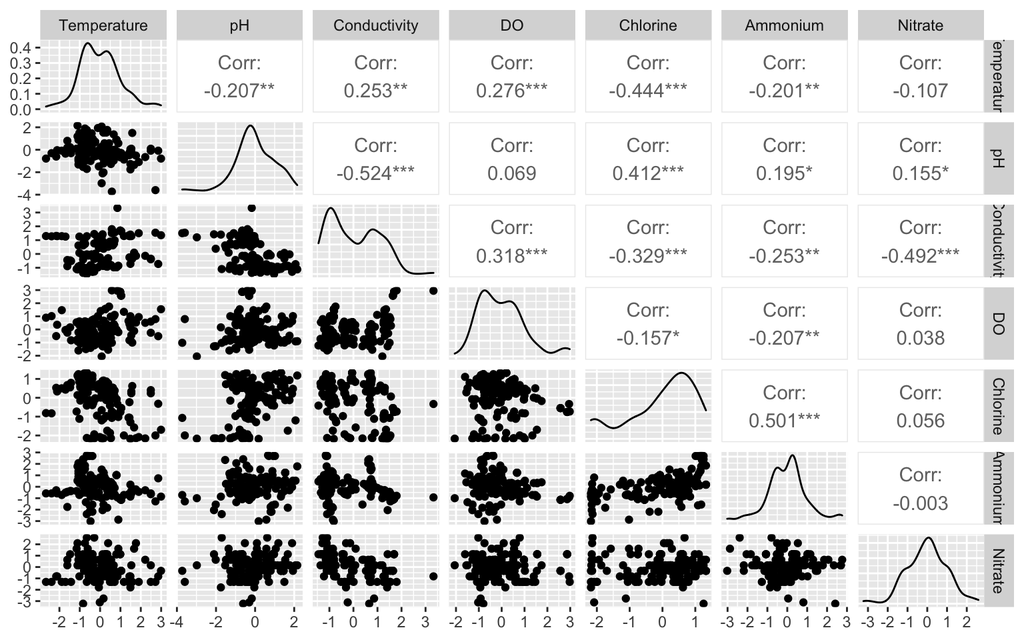

```r
EnvData_transformed <- scale(EnvData %>% dplyr::select(-Property, -Season)) %>% as.data.frame()

GGally::ggpairs(EnvData_transformed)
```

```r
EnvData_groupings <- EnvData %>% dplyr::select(Property, Season) %>% mutate(category = str_remove(Property,
    "[:digit:]+"))

EnvData_groupings %>% group_by(category) %>% tally
```

```
# A tibble: 2 x 2
  category     n
* <chr>    <int>
1 COM        113
2 RES         52
```

```r
EnvData_groupings %>% group_by(Season) %>% tally
```

```
# A tibble: 2 x 2
  Season     n
* <chr>  <int>
1 Fall      81
2 Summer    84
```

```r
###################################################################

flowData_transformed <- flowCore::transform(flowData, `FL1-H` = asinh(`FL1-H`), `SSC-H` = asinh(`SSC-H`),
    `FL3-H` = asinh(`FL3-H`), `FSC-H` = asinh(`FSC-H`))

subset_FC_arscsin <- flowData_transformed@frames[["B01 COM02_TCC_TP02_R1.fcs"]]@exprs %>%
    as.tibble() %>% select(`FL1-H`, `FL3-H`, `SSC-H`, `FSC-H`)
```

### Denoise and gating

Choose features (i.e., channels) and remove instrument/sample noise with `PolygonGate` function. This function will extract observations bounded by the gate as a subset of the full data set. Further all values will be normalized by green fluorescence channel.

The `flowBasis` function from `flowFDA` calculates the phenotypic fingerprints.

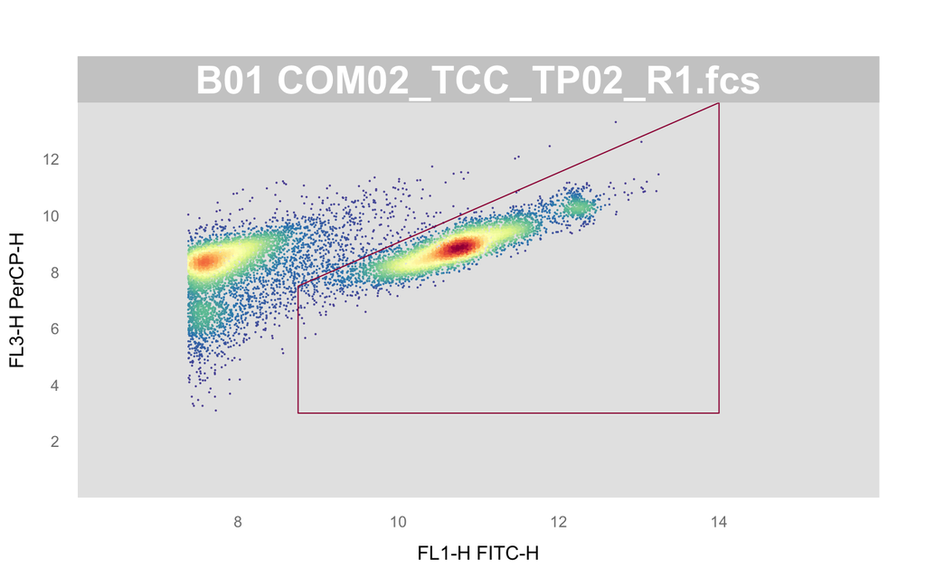

```r
param<- c("FL1-H", "FL3-H","SSC-H","FSC-H") #green, red, scatter - height
sqrcut1 <- matrix(c(8.75,8.75,14,14,3,7.5,14,3),ncol=2, nrow=4) # gate coordinates in format: c(x,x,x,x,y,y,y,y)
colnames(sqrcut1) <- c("FL1-H","FL3-H")
polyGate1 <- flowCore::polygonGate(.gate=sqrcut1, filterId = "Total Cells")

# Gating quality check
flowViz::xyplot(`FL3-H` ~ `FL1-H`,
       data=flowData_transformed[1],
       filter=polyGate1,
       scales=list(y=list(limits=c(0,14)),
                   x=list(limits=c(6,16))),
       axis = axis.default, nbin=125,
       par.strip.text=list(col="white", font=2, cex=2),
       smooth=FALSE)
```

```r
# Isolate only the cellular information based on the polyGate1
flowData_transformed <- flowCore::Subset(flowData_transformed, polyGate1)

subset_FC_arscsin_gate<- flowData_transformed@frames[["B01 COM02_TCC_TP02_R1.fcs"]]@exprs %>%
  as.tibble() %>%
  select(`FL1-H`, `FL3-H`, `SSC-H`, `FSC-H`)

summary <- flowCore::fsApply(x = flowData_transformed,
                   FUN = function(x) apply(x, 2, max),
                   use.exprs = TRUE) #for each channel obtain max value

maxval <- max(summary[,"FL1-H"])  #extract max value corresponding to green fluorescent channel out of all samples
mytrans <- function(x) x/maxval

flowData_transformed <- flowCore::transform(flowData_transformed,
                                  `FL1-H`=mytrans(`FL1-H`),
                                  `FL3-H`=mytrans(`FL3-H`),
                                  `SSC-H`=mytrans(`SSC-H`),
                                  `FSC-H`=mytrans(`FSC-H`))

subset_FC_arscsin_gate_maxG<- flowData_transformed@frames[["B01 COM02_TCC_TP02_R1.fcs"]]@exprs %>%
  as.tibble() %>%
  select(`FL1-H`, `FL3-H`, `SSC-H`, `FSC-H`)

#Fingerprints
fbasis<- flowFDA::flowBasis(flowData_transformed,
                           param, #channels for which the bivariate density basis are derived
                           nbin=128, #Number of bins that are taken in each channel to approximate the bivariate densities
                           bw=0.01, #Bandwidth of for the kernel density estimator calculated at each bin
                           normalize=function(x) x) # A user defined function for rescaling or normalising the densities, standard the density estimates are rescaled between 0 and 1
```

## PCA

We will perform Principal Component analyses using environmental data.

How many dimensions should we focus on?  
* See scree plot (elbow)  
* Kaiser-Guttman criterion: Selects principal components which capture more variance than the average of all PCs

```r
res.pca <- prcomp(EnvData_transformed)  #we can also use the scale and center arguments here
res.pca2 <- vegan::rda(EnvData_transformed)  #another option

res.pca
```

```
Standard deviations (1, .., p=7):
[1] 1.5930208 1.1413020 1.0286248 0.8859235 0.8368900 0.6172986 0.4851210

Rotation (n x k) = (7 x 7):
                    PC1        PC2        PC3         PC4        PC5
Temperature  -0.3760278 -0.2379436  0.1510880 -0.76373778  0.1888404
pH            0.3997495 -0.2805221  0.4426908  0.06150970  0.5580176
Conductivity -0.4827663  0.3543206  0.2294426  0.20423508 -0.2417205
DO           -0.2409309 -0.3683077  0.7079111  0.17854692 -0.3368720
Chlorine      0.4705470  0.2552709  0.3192276  0.09378759 -0.1729019
Ammonium      0.3644849  0.3628830  0.2106926 -0.57453272 -0.3900228
Nitrate       0.2311463 -0.6376905 -0.2848115 -0.02112419 -0.5468375
                     PC6         PC7
Temperature   0.39547374  0.06166661
pH           -0.17837907  0.46748948
Conductivity  0.06785708  0.69570418
DO           -0.15822497 -0.36710580
Chlorine      0.75361914 -0.06987875
Ammonium     -0.45070383  0.07573466
Nitrate       0.10519480  0.38504683
```

```r
summary(res.pca2)
```

```
Call:
rda(X = EnvData_transformed)

Partitioning of variance:
              Inertia Proportion
Total               7          1
Unconstrained       7          1

Eigenvalues, and their contribution to the variance

Importance of components:
                         PC1    PC2    PC3    PC4    PC5     PC6     PC7
Eigenvalue            2.5377 1.3026 1.0581 0.7849 0.7004 0.38106 0.23534
Proportion Explained  0.3625 0.1861 0.1512 0.1121 0.1001 0.05444 0.03362
Cumulative Proportion 0.3625 0.5486 0.6998 0.8119 0.9119 0.96638 1.00000

Scaling 2 for species and site scores
* Species are scaled proportional to eigenvalues
* Sites are unscaled: weighted dispersion equal on all dimensions
* General scaling constant of scores:  5.820837


Species scores

                 PC1     PC2     PC3      PC4     PC5      PC6
Temperature  -1.3179 -0.5975  0.3419 -1.48860  0.3477  0.53709
pH            1.4010 -0.7044  1.0018  0.11989  1.0274 -0.24226
Conductivity -1.6920  0.8897  0.5192  0.39807 -0.4451  0.09216
DO           -0.8444 -0.9248  1.6020  0.34800 -0.6203 -0.21489
Chlorine      1.6492  0.6410  0.7224  0.18280 -0.3183  1.02349
Ammonium      1.2774  0.9112  0.4768 -1.11982 -0.7181 -0.61210
Nitrate       0.8101 -1.6012 -0.6445 -0.04117 -1.0068  0.14287


Site scores (weighted sums of species scores)

                   PC1       PC2       PC3       PC4        PC5        PC6
SW001        -0.426413  0.141714  0.227509  0.099349 -0.0448595  5.202e-01
SW002        -0.108463  0.685728  0.109371  0.969041  0.0208771 -7.442e-02
SW003        -0.202475  0.638114  0.166642  0.490670  0.0825077  1.787e-01
SW004         0.001846  0.749287 -0.139614  1.040325 -0.2261993 -9.429e-02
SW005        -0.495838  0.254669  0.619836 -0.259895  0.2303408  6.512e-01
SW006        -0.179647  0.433342  0.616849  1.256154 -0.1621922 -2.274e-01
SW007        -0.727772  0.145549  0.290418 -0.209156  0.3322573 -9.462e-03
SW008        -0.282002  0.455008  0.222859  1.297848 -0.1002306 -1.076e+00
SW009        -0.661319  0.010161  0.193447 -0.230044  0.3205139  6.009e-02
SW010        -0.300769  0.556748  0.076336  1.381540 -0.2565427 -1.071e+00
SW011        -0.993736  0.064012  0.102854 -0.312909  0.1283274 -5.698e-01
SW012        -0.925695 -0.002184  0.274252 -0.096524  0.1686159 -6.072e-01
 [ reached getOption("max.print") -- omitted 153 rows ]
```

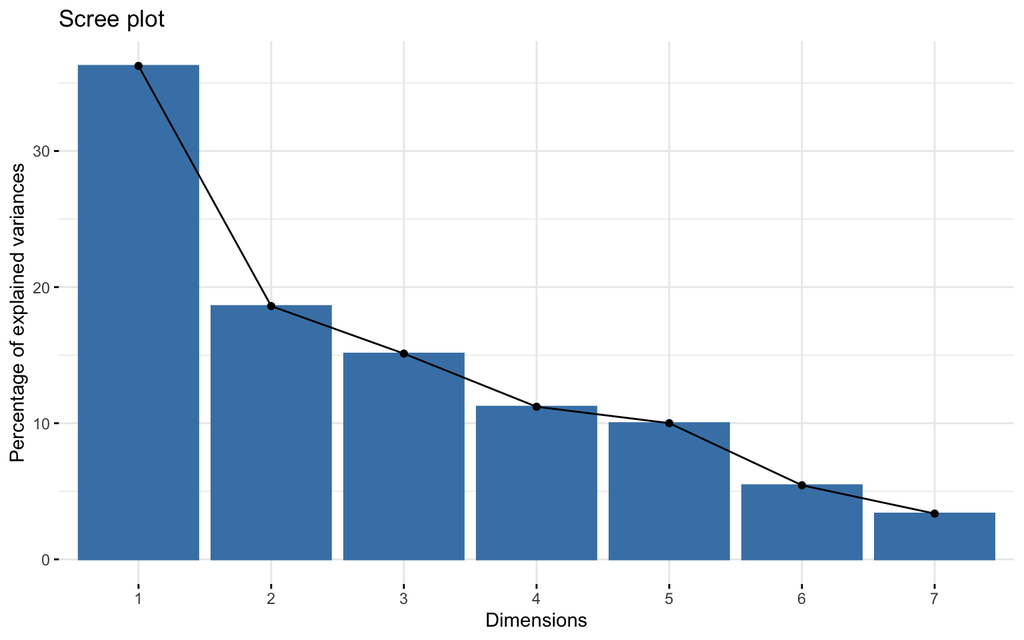

```r
fviz_eig(res.pca)  #scree plot
```

```r
## Extract eigenvalues (variance, stretching)
Eigenvalues.pca <- vegan::eigenvals(res.pca)

Eigenvalues.pca[Eigenvalues.pca > mean(Eigenvalues.pca)]  #Kaiser-Guttman
```

```
     PC1      PC2      PC3
2.537715 1.302570 1.058069
```

```r
## Variance information
Variance.pca <- Eigenvalues.pca/sum(Eigenvalues.pca)
Variance.pca.1 <- as.numeric(100 * signif(Variance.pca[1], 4))
Variance.pca.2 <- as.numeric(100 * signif(Variance.pca[2], 4))
Variance.pca.3 <- as.numeric(100 * signif(Variance.pca[3], 4))

## Extract loadings (Eigenvectors, variable coordinates)
loadings.pca <- res.pca$rotation

## Standard deviation information
sdev.pca <- res.pca$sdev

## Coordinates
var_coord_func <- function(loadings, comp.sdev) {
    loadings * comp.sdev
}

var.coord.pca <- loadings.pca %>% as_tibble() %>% rowwise() %>% purrr::map2(., sdev.pca,
    var_coord_func) %>% bind_rows() %>% as.data.frame()

rownames(var.coord.pca) <- rownames(loadings.pca)

var.cos.pca <- var.coord.pca^2  #compute Cos2 (the variable components squared), or quality of representation on given dimension
comp.cos.pca <- var.cos.pca %>% summarise_all(sum)

## Contributions
contrib.pca_func <- function(var.cos.pca, comp.cos.pca) {
    var.cos.pca * 100/comp.cos.pca
}
var.contrib.pca <- var.cos.pca %>% as_tibble() %>% rowwise() %>% purrr::map2(., comp.cos.pca,
    contrib.pca_func) %>% bind_rows() %>% as.data.frame()

rownames(var.contrib.pca) <- rownames(var.cos.pca)

res.pca.out <- res.pca$x[, c("PC1", "PC2")] %>% as.data.frame() %>% tibble::rownames_to_column("Sample.Id") %>%
    left_join(EnvData_groupings %>% rownames_to_column("Sample.Id"))
```

### Visualization

We will visualize the PCA as a biplot, where samples are positioned in terms of PC1 and PC2 (i.e., observations) and the initial variables are mapped onto the plot as well. With this type of graphs, you can explore the trends in the data samples and features simultaneously.

Because eigenvalues reflect the variance in coordinates of the associated PCs, you only need to ensure that in the plots, one “unit” in direction of one PC has the same length as one “unit” in direction of another PC. (If you use ggplot2 R package for generating plots, adding + coord_fixed(1) will ensure a correct aspect ratio.)

The interpretation of the PCA biplot (loadings + scores):  
* variables association with principal components  
* variable relationships among themselves:  
- Descriptors at 180 degrees of each other are negatively correlated  
- Descriptors at 90 degrees of each other have zero correlation  
- Descriptors at 0 degrees of each other are positively correlated

**Side note**: snippets help you type less!

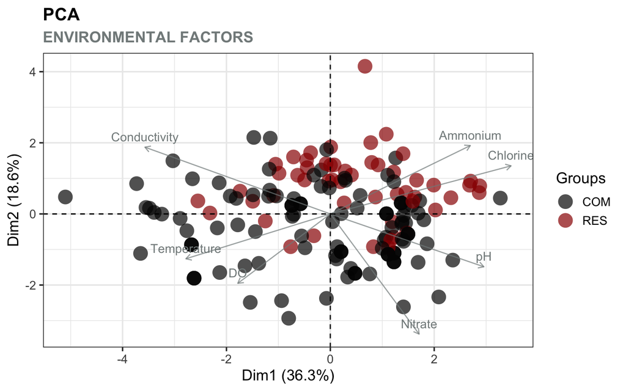

```r
p <- fviz_pca_biplot(res.pca, geom = "point", pointsize = 6, habillage = EnvData_groupings$category,
    invisible = "quali", col.var = "azure4", alpha = 0.7) + scale_color_manual(values = c("grey1",
    "#990000")) + scale_shape_manual(values = c(16, 16)) + labs(title = "PCA", subtitle = "ENVIRONMENTAL FACTORS") +
    theme_bw(base_size = 14) + theme(plot.title = element_text(face = "bold", size = 16),
    legend.title = element_text(face = "plain", size = 14), plot.subtitle = element_text(face = "bold",
        size = 14, color = "azure4"), legend.position = "right")

# library(usethis) usethis::edit_rstudio_snippets()

data_arrow <- loadings.pca %>% as.data.frame() %>% select(PC1, PC2) %>% mutate_all(function(x) x *
    10) %>% rownames_to_column("variable")

p2 <- ggplot() + geom_point(data = res.pca.out, aes(PC1, PC2, color = category),
    alpha = 0.7, size = 6) + geom_hline(yintercept = 0, linetype = "dotted") + geom_vline(xintercept = 0,
    linetype = "dotted") + geom_segment(data = data_arrow, aes(x = 0, y = 0, xend = PC1,
    yend = PC2), arrow = arrow(length = unit(0.1, "inches")), lineend = "round",
    linejoin = "round", color = "gray") + geom_text(data = data_arrow, aes(x = PC1,
    y = PC2, label = variable), hjust = "outside", nudge_x = 0.2, color = "gray") +
    xlab(paste0("PC1 (", Variance.pca.1, "%)")) + ylab(paste0("PC2 (", Variance.pca.2,
    "%)")) + scale_color_manual(values = c("grey1", "#990000")) + scale_shape_manual(values = c(16,
    16)) + labs(title = "PCA", subtitle = "ENVIRONMENTAL FACTORS") + theme_bw(base_size = 14) +
    theme(plot.title = element_text(face = "bold", size = 16), legend.title = element_text(face = "plain",
        size = 14), plot.subtitle = element_text(face = "bold", size = 14, color = "azure4"),
        legend.position = "right") + coord_fixed(1)

p
```

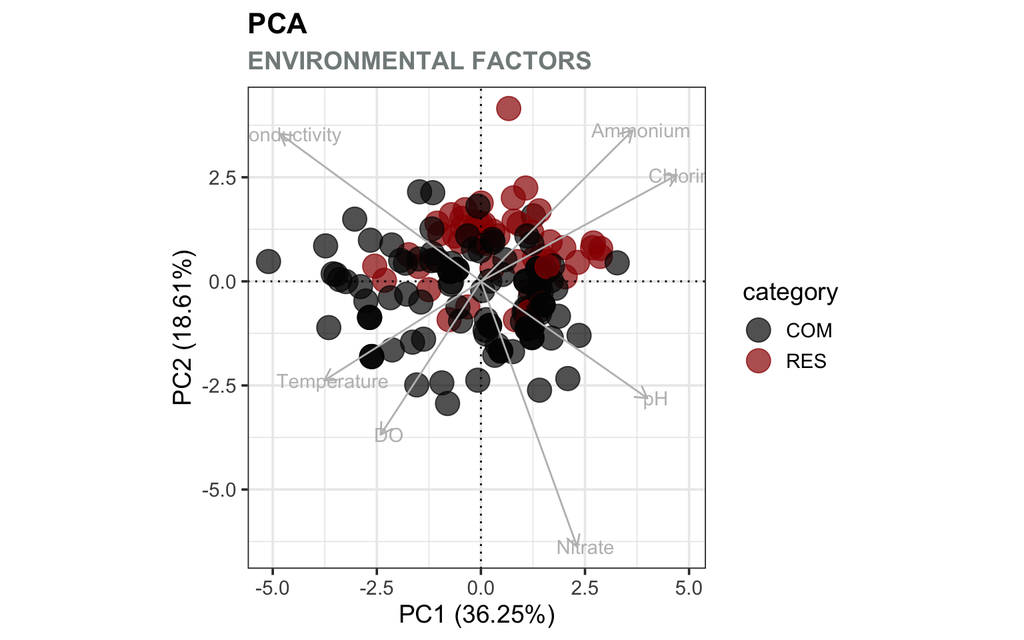

```r
p2
```

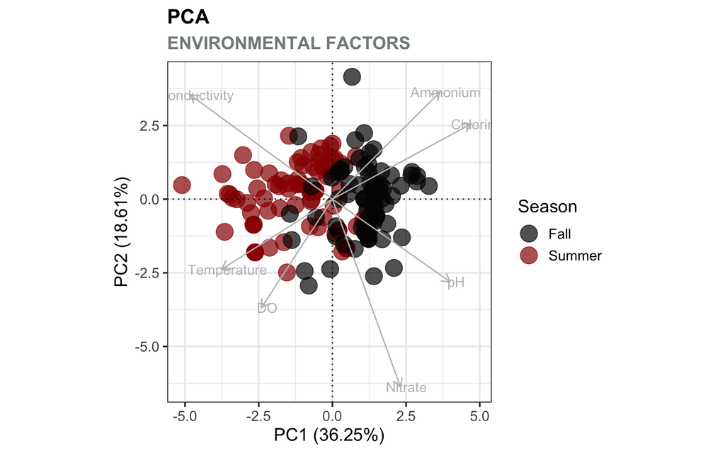

```r
p3 <- ggplot() + geom_point(data = res.pca.out, aes(PC1, PC2, color = Season), alpha = 0.7,
    size = 6) + geom_hline(yintercept = 0, linetype = "dotted") + geom_vline(xintercept = 0,
    linetype = "dotted") + geom_segment(data = data_arrow, aes(x = 0, y = 0, xend = PC1,
    yend = PC2), arrow = arrow(length = unit(0.1, "inches")), lineend = "round",
    linejoin = "round", color = "gray") + geom_text(data = data_arrow, aes(x = PC1,
    y = PC2, label = variable), hjust = "outside", nudge_x = 0.2, color = "gray") +
    xlab(paste0("PC1 (", Variance.pca.1, "%)")) + ylab(paste0("PC2 (", Variance.pca.2,
    "%)")) + scale_color_manual(values = c("grey1", "#990000")) + scale_shape_manual(values = c(16,
    16)) + labs(title = "PCA", subtitle = "ENVIRONMENTAL FACTORS") + theme_bw(base_size = 14) +
    theme(plot.title = element_text(face = "bold", size = 16), legend.title = element_text(face = "plain",
        size = 14), plot.subtitle = element_text(face = "bold", size = 14, color = "azure4"),
        legend.position = "right") + coord_fixed(1)

p3
```

## PCoA

The PCoA for FC data preserves Bray-Curtis distances and results from a matrix of features corresponding to the previously chosen parameters (i.e., “FL1-H”, “FL3-H”,“SSC-H”,“FSC-H”).

This calculation corresponds to beta-analyses of the fingerprints, using density values.

According to Props et al. 2016

> Phenoflow: data processing pipeline that ﬁts [**bivariate kernel density functions**](https://machinelearningmastery.com/probability-density-estimation/) to phenotypic parameter combinations of an entire microbial community and concatenates them to a single one-dimensional phenotypic ﬁngerprint. By calculating established diversity metrics from such phenotypic ﬁngerprints, we construct an alternative interpretation of the microbial diversity that incorporates distinct phenotypic traits underlying cell-to-cell heterogeneity (i.e. morphology and nucleic acid content)

```r
PCoA_mat <- fbasis@basis

flowDataBC <- beta.div.fcm(fbasis, n = 1, ord.type = "PCoA")  # sourced function, based on Bray-Curtis distances, using cmdscale (stats)

str(flowDataBC)
```

```
List of 5
 $ points: num [1:231, 1:2] 0.1761 0.0263 0.3344 -0.0822 -0.1606 ...
  ..- attr(*, "dimnames")=List of 2
  .. ..$ : chr [1:231] "B01 COM02_TCC_TP02_R1.fcs" "B01 COM03_TCC_TP02_R1.fcs" "B01 COM05_TCC_TP02_R1.fcs" "B01 RES01_TCC_TP02_R1.fcs" ...
  .. ..$ : NULL
 $ eig   : num [1:231] 6.09 2.97 1.85 1.51 1.21 ...
 $ x     : NULL
 $ ac    : num 0.167
 $ GOF   : num [1:2] 0.315 0.315
```

```r
class(flowDataBC)
```

```
[1] "list"
```

```r
Variance.pcoa <- vegan::eigenvals(flowDataBC)/sum(vegan::eigenvals(flowDataBC))


flowData_groupings <- readxl::read_excel("data/sample.database.xlsx", sheet = "Chemical_data") %>%
    select(Property, Time.point, Replicate, Season) %>% rename(Time.Point = "Time.point",
    Location = "Property") %>% mutate(Replicate = str_remove(Replicate, "0"))

flowDataBC_PCoApoints <- flowDataBC %>% purrr::simplify() %>% dplyr::first() %>%
    as.data.frame() %>% tibble::rownames_to_column("fcs.id") %>% rename(PC1 = "V1",
    PC2 = "V2") %>% tidyr::separate(fcs.id, into = c("Well", "col01"), sep = " ") %>%
    tidyr::separate(col01, into = c("Location", "Stain", "Time.Point", "Replicate"),
        sep = "_") %>% tidyr::separate(Replicate, into = c("Replicate", "col06"),
    sep = ".fcs") %>% select(-col06) %>% mutate(Site = case_when(grepl("COM", Location) ~
    "Commercial", TRUE ~ "Residential")) %>% dplyr::filter(Stain == "TCC") %>% dplyr::filter(Time.Point %in%
    c("TP01", "TP02", "TP03", "TP04", "TP05", "TP06", "TP07")) %>% left_join(flowData_groupings)
```

### Visualization

Interpretation of a PCoA plot is straightforward: objects ordinated closer to one another are more similar than those ordinated further away.

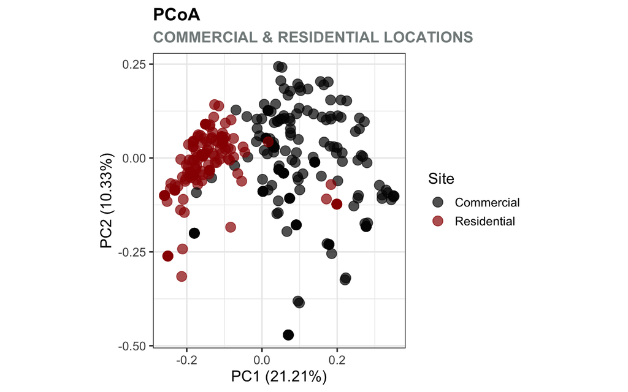

```r
p4 <- ggplot(flowDataBC_PCoApoints, aes(x = PC1, y = PC2)) + geom_point(size = 4,
    aes(colour = Site), alpha = 0.7) + theme_bw(base_size = 14) + theme(plot.title = element_text(face = "bold",
    size = 16), legend.title = element_text(face = "plain", size = 14), plot.subtitle = element_text(face = "bold",
    size = 14, color = "azure4"), legend.position = "right") + labs(x = paste0("PC1 (",
    round(100 * Variance.pcoa[1], 2), "%)"), colour = "Site", y = paste0("PC2 (",
    round(100 * Variance.pcoa[2], 2), "%)"), title = "PCoA", subtitle = "COMMERCIAL & RESIDENTIAL LOCATIONS") +
    scale_color_manual(values = c("grey1", "#990000")) + coord_fixed(1)

p4
```